# Predicting Absenteeism at work

Machine Learning II

Sandra Alemayehu & Jessica Hayek

February 21, 2020

# 1 Introduction

The main goal is to **predict whether or not an individual is going to have a long absence** (`Absenteeism` variable) it’s therefore a binary classification problem. Absenteeism is when an employee has intential, repeated and prolonged absences from work. Although the causes of absenteeism are still not fully grasped by employers, its effects on productivity are understood to be great on productivity.

Through our project, we aim to help companies identify the predictors of absenteeism, which will allow a proper implementation of solutions to reduce it. As such, our problem is a classification problem with “Absenteeism” as our target variable, with “0” meaning “no absenteeism” and “1” meaning “absenteeism”.

# 2 Data Loading and Overview

```r
abs_trainset_df<-read.csv("C:/Users/sandr/Desktop/Machine Learning II/ML Assignment/Absenteeism_at_work_classification/Absenteeism_at_work_classification_training.csv",header = TRUE, sep = ";")
ncol(abs_trainset_df)
```

```
## [1] 22
```

```r
abs_testset_df = read.csv(file = file.path("C:/Users/sandr/Desktop/Machine Learning II/ML Assignment/Absenteeism_at_work_classification/Absenteeism_at_work_classification_test.csv"),  header = TRUE, dec = ".", sep = ";")
```

## 2.1 Variable Type

```r
data.frame(Variable = names(abs_trainset_df),
           Type = sapply(abs_trainset_df, typeof),
           Min=sapply(abs_trainset_df, min),
           Max=sapply(abs_trainset_df, max),
           First_values = sapply(abs_trainset_df, function(x) paste0(head(x),  collapse = ", ")),
           row.names = NULL) %>% kable()
```

| Variable | Type | Min | Max | First_values |
| --- | --- | --- | --- | --- |
| ID | integer | 1.000 | 740.000 | 1, 2, 3, 4, 5, 7 |
| Reason.for.absence | integer | 0.000 | 28.000 | 26, 0, 23, 7, 23, 22 |
| Month.of.absence | integer | 0.000 | 12.000 | 7, 7, 7, 7, 7, 7 |
| Day.of.the.week | integer | 2.000 | 6.000 | 3, 3, 4, 5, 5, 6 |
| Seasons | integer | 1.000 | 4.000 | 1, 1, 1, 1, 1, 1 |
| Transportation.expense | integer | 118.000 | 388.000 | 289, 118, 179, 279, 289, 361 |
| Distance.from.Residence.to.Work | integer | 5.000 | 52.000 | 36, 13, 51, 5, 36, 52 |
| Service.time | integer | 1.000 | 29.000 | 13, 18, 18, 14, 13, 3 |
| Age | integer | 27.000 | 58.000 | 33, 50, 38, 39, 33, 28 |
| Work.load.Average.day | double | 205.917 | 378.884 | 239.554, 239.554, 239.554, 239.554, 239.554, 239.554 |
| Hit.target | integer | 81.000 | 100.000 | 97, 97, 97, 97, 97, 97 |
| Disciplinary.failure | integer | 0.000 | 1.000 | 0, 1, 0, 0, 0, 0 |
| Education | integer | 1.000 | 4.000 | 1, 1, 1, 1, 1, 1 |
| Son | integer | 0.000 | 4.000 | 2, 1, 0, 2, 2, 1 |
| Social.drinker | integer | 0.000 | 1.000 | 1, 1, 1, 1, 1, 1 |
| Social.smoker | integer | 0.000 | 1.000 | 0, 0, 0, 1, 0, 0 |
| Pet | integer | 0.000 | 8.000 | 1, 0, 0, 0, 1, 4 |
| Weight | integer | 56.000 | 108.000 | 90, 98, 89, 68, 90, 80 |
| Height | integer | 163.000 | 196.000 | 172, 178, 170, 168, 172, 172 |
| Body.mass.index | integer | 19.000 | 38.000 | 30, 31, 31, 24, 30, 27 |
| ID.Worker | integer | 1.000 | 36.000 | 11, 36, 3, 7, 11, 10 |
| Absenteeism | logical | 0.000 | 1.000 | FALSE, FALSE, FALSE, FALSE, FALSE, TRUE |

The dataframe contains **22** variables.The target variable is **Absenteeism**, a logical variable setting categorizing whether an individual is going to be absent more than 5 hours in total.

## 2.2 Data overview

Lets look at the statistical summary and histogram of each variable.

Data summary

| Name | abs_trainset_df |
| --- | --- |
| Number of rows | 593 |
| Number of columns | 22 |
| _______________________ |  |
| Column type frequency: |  |
| logical | 1 |
| numeric | 21 |
| ________________________ |  |
| Group variables | None |

**Variable type: logical**

| skim_variable | n_missing | complete_rate | mean | count |
| --- | --- | --- | --- | --- |
| Absenteeism | 0 | 1 | 0.37 | FAL: 375, TRU: 218 |

**Variable type: numeric**

| skim_variable | n_missing | complete_rate | mean | sd | p0 | p25 | p50 | p75 | p100 | hist |
| --- | --- | --- | --- | --- | --- | --- | --- | --- | --- | --- |
| ID | 0 | 1 | 375.23 | 213.60 | 1.00 | 190.00 | 383.00 | 558.00 | 740.00 | ▇▇▇▇▇ |
| Reason.for.absence | 0 | 1 | 19.07 | 8.53 | 0.00 | 13.00 | 23.00 | 27.00 | 28.00 | ▁▂▂▂▇ |
| Month.of.absence | 0 | 1 | 6.28 | 3.40 | 0.00 | 3.00 | 6.00 | 9.00 | 12.00 | ▅▆▇▅▇ |
| Day.of.the.week | 0 | 1 | 3.92 | 1.41 | 2.00 | 3.00 | 4.00 | 5.00 | 6.00 | ▇▇▇▆▇ |
| Seasons | 0 | 1 | 2.56 | 1.10 | 1.00 | 2.00 | 3.00 | 4.00 | 4.00 | ▇▇▁▇▇ |
| Transportation.expense | 0 | 1 | 222.20 | 65.31 | 118.00 | 179.00 | 225.00 | 260.00 | 388.00 | ▃▇▅▃▁ |
| Distance.from.Residence.to.Work | 0 | 1 | 29.97 | 14.63 | 5.00 | 17.00 | 26.00 | 50.00 | 52.00 | ▅▃▇▂▆ |
| Service.time | 0 | 1 | 12.62 | 4.36 | 1.00 | 9.00 | 13.00 | 16.00 | 29.00 | ▁▇▆▃▁ |
| Age | 0 | 1 | 36.42 | 6.53 | 27.00 | 31.00 | 37.00 | 40.00 | 58.00 | ▇▇▃▂▁ |
| Work.load.Average.day | 0 | 1 | 271.81 | 39.63 | 205.92 | 244.39 | 264.25 | 294.22 | 378.88 | ▅▇▃▂▁ |
| Hit.target | 0 | 1 | 94.54 | 3.83 | 81.00 | 92.00 | 95.00 | 97.00 | 100.00 | ▁▁▃▇▇ |
| Disciplinary.failure | 0 | 1 | 0.05 | 0.22 | 0.00 | 0.00 | 0.00 | 0.00 | 1.00 | ▇▁▁▁▁ |
| Education | 0 | 1 | 1.30 | 0.68 | 1.00 | 1.00 | 1.00 | 1.00 | 4.00 | ▇▁▁▁▁ |
| Son | 0 | 1 | 1.02 | 1.11 | 0.00 | 0.00 | 1.00 | 2.00 | 4.00 | ▇▆▅▁▁ |
| Social.drinker | 0 | 1 | 0.56 | 0.50 | 0.00 | 0.00 | 1.00 | 1.00 | 1.00 | ▆▁▁▁▇ |
| Social.smoker | 0 | 1 | 0.07 | 0.26 | 0.00 | 0.00 | 0.00 | 0.00 | 1.00 | ▇▁▁▁▁ |
| Pet | 0 | 1 | 0.72 | 1.22 | 0.00 | 0.00 | 0.00 | 1.00 | 8.00 | ▇▂▁▁▁ |
| Weight | 0 | 1 | 78.49 | 12.88 | 56.00 | 68.00 | 80.00 | 89.00 | 108.00 | ▅▇▅▇▂ |
| Height | 0 | 1 | 171.95 | 5.87 | 163.00 | 169.00 | 170.00 | 172.00 | 196.00 | ▃▇▁▁▁ |
| Body.mass.index | 0 | 1 | 26.54 | 4.28 | 19.00 | 23.00 | 25.00 | 31.00 | 38.00 | ▃▇▃▅▁ |
| ID.Worker | 0 | 1 | 18.08 | 10.88 | 1.00 | 10.00 | 19.00 | 28.00 | 36.00 | ▇▇▆▇▆ |

# 3 Data Cleaning and Preparation

## 3.1 Changing Data Type

We can see from the attribute information (https://archive.ics.uci.edu/ml/datasets/Absenteeism+at+work) that 11 categorical variables have been codified as number in our dataframe. These variables are: **ID**, **ID.Worker**, **Reason.for.absence**, **Month.of.absence**, **Day.of.the.week**, **Seasons**, **Disciplinary.failure**, **Education**, **Social.drinker**, **Social.smoker**,**Absenteeism** Before converting these these variables need to combine test dataset with train dataset, and apply the conversion on both.

```
## 'data.frame':    740 obs. of  22 variables:
##  $ ID                             : int  1 2 3 4 5 7 9 10 11 12 ...
##  $ Reason.for.absence             : int  26 0 23 7 23 22 19 22 1 1 ...
##  $ Month.of.absence               : int  7 7 7 7 7 7 7 7 7 7 ...
##  $ Day.of.the.week                : int  3 3 4 5 5 6 2 2 2 3 ...
##  $ Seasons                        : int  1 1 1 1 1 1 1 1 1 1 ...
##  $ Transportation.expense         : int  289 118 179 279 289 361 155 235 260 260 ...
##  $ Distance.from.Residence.to.Work: int  36 13 51 5 36 52 12 11 50 50 ...
##  $ Service.time                   : int  13 18 18 14 13 3 14 14 11 11 ...
##  $ Age                            : int  33 50 38 39 33 28 34 37 36 36 ...
##  $ Work.load.Average.day          : num  240 240 240 240 240 ...
##  $ Hit.target                     : int  97 97 97 97 97 97 97 97 97 97 ...
##  $ Disciplinary.failure           : int  0 1 0 0 0 0 0 0 0 0 ...
##  $ Education                      : int  1 1 1 1 1 1 1 3 1 1 ...
##  $ Son                            : int  2 1 0 2 2 1 2 1 4 4 ...
##  $ Social.drinker                 : int  1 1 1 1 1 1 1 0 1 1 ...
##  $ Social.smoker                  : int  0 0 0 1 0 0 0 0 0 0 ...
##  $ Pet                            : int  1 0 0 0 1 4 0 1 0 0 ...
##  $ Weight                         : int  90 98 89 68 90 80 95 88 65 65 ...
##  $ Height                         : int  172 178 170 168 172 172 196 172 168 168 ...
##  $ Body.mass.index                : int  30 31 31 24 30 27 25 29 23 23 ...
##  $ ID.Worker                      : int  11 36 3 7 11 10 14 1 20 20 ...
##  $ Absenteeism                    : num  0 0 0 0 0 1 1 1 1 1 ...
```

We can now convert all the categorical variables to factors.

| Variable | Class | First_values |
| --- | --- | --- |
| ID | factor | 1, 2, 3, 4, 5, 7 |
| Reason.for.absence | factor | 26, 0, 23, 7, 23, 22 |
| Month.of.absence | factor | 7, 7, 7, 7, 7, 7 |
| Day.of.the.week | factor | 3, 3, 4, 5, 5, 6 |
| Seasons | factor | 1, 1, 1, 1, 1, 1 |
| Transportation.expense | integer | 289, 118, 179, 279, 289, 361 |
| Distance.from.Residence.to.Work | integer | 36, 13, 51, 5, 36, 52 |
| Service.time | integer | 13, 18, 18, 14, 13, 3 |
| Age | integer | 33, 50, 38, 39, 33, 28 |
| Work.load.Average.day | numeric | 239.554, 239.554, 239.554, 239.554, 239.554, 239.554 |
| Hit.target | integer | 97, 97, 97, 97, 97, 97 |
| Disciplinary.failure | factor | 0, 1, 0, 0, 0, 0 |
| Education | factor | 1, 1, 1, 1, 1, 1 |
| Son | integer | 2, 1, 0, 2, 2, 1 |
| Social.drinker | factor | 1, 1, 1, 1, 1, 1 |
| Social.smoker | factor | 0, 0, 0, 1, 0, 0 |
| Pet | integer | 1, 0, 0, 0, 1, 4 |
| Weight | integer | 90, 98, 89, 68, 90, 80 |
| Height | integer | 172, 178, 170, 168, 172, 172 |
| Body.mass.index | integer | 30, 31, 31, 24, 30, 27 |
| ID.Worker | factor | 11, 36, 3, 7, 11, 10 |
| Absenteeism | factor | 0, 0, 0, 0, 0, 1 |

To make attributes more discriptive we will add the actual category names of variables **Education**, **Seasons**, and **Reason for Absence**.

```r
abs_dataset$Reason.for.absence <- recode(abs_dataset$Reason.for.absence,
                                     '0'='Infectious_parasitic_diseases',
                                     '1'='Neoplasms',
                                     '2'='Diseases_of_the_blood',
                                     '3'='Endocrine_and_metabolic_diseases',
                                     '4'='Mental_and_behavioural_disorders',
                                     '5'='Diseases_of_the_nervous_system',
                                     '6'='Diseases_of_the_eye_and_adnexa',
                                     '7'='Diseases_of_the_ear_and_mastoid_process',
                                     '8'='Diseases_of_the_circulatory_system',
                                     '9'='Diseases_of_the_respiratory_system',
                                     '10'='Diseases_of_the_digestive_system',
                                     '11'='Diseases_of_the_skin_and_subcutaneous_tissue',
                                     '12'='Diseases_of_the_musculoskeletal_system_and_connective_tissue',
                                     '13'='Diseases_of_the_genitourinary_system',
                                     '14'='Pregnancy_childbirth_andthe_puerperium',
                                     '15'='Certain_conditions_originating_in_the_perinatal',
                                     '16'='Congenital_malformations_deformations_and_chromosomal_abnormalities',
                                     '17'='Symptoms_signs_and_abnormal_clinica_findings',
                                     '18'='Injury_poisoning_and_certain_other_consequences_of_external_causes',
                                     '19'='causes_of_morbidity_and_mortality',
                                     '21'='Factors_influencing_health_status_and_contact_with_health_services',
                                     '22'='patient_follow-up',
                                     '23'='medical_consultation',
                                     '24'='blood_donation',
                                     '25'='laboratory_examination',
                                     '26'='unjustified_absence',
                                     '27'='physiotherapy',
                                     '28'='dental_consultation')

abs_dataset$Seasons =recode(abs_dataset$Seasons,'1'='summer','2'='autumn','3'='winter','4'='spring')

abs_dataset$Education =recode(abs_dataset$Education, '1'='highschool','2'='graduate','3'='postgraduate','4'='master&PhD')

#Check dataset again
str(abs_dataset$Seasons)
```

```
##  Factor w/ 4 levels "summer","autumn",..: 1 1 1 1 1 1 1 1 1 1 ...
```

```r
str(abs_dataset$Education)
```

```
##  Factor w/ 4 levels "highschool","graduate",..: 1 1 1 1 1 1 1 3 1 1 ...
```

```r
str(abs_dataset$Reason.for.absence)
```

```
##  Factor w/ 28 levels "Infectious_parasitic_diseases",..: 26 1 23 8 23 22 20 22 2 2 ...
```

```r
str(abs_dataset$Absenteeism)
```

```
##  Factor w/ 2 levels "0","1": 1 1 1 1 1 2 2 2 2 2 ...
```

The target variable already has One Hot Encoding and we dont need to make further changes to it.

## 3.2 Check for Duplicate Observations

Our unique identifier in the dataset is the **ID** variable and we can use that to see if we have variables that have been duplicated. We do this for just the training part of the data set which is the first 593 records.

```r
print(paste0("The total number of duplicates in our dataframe is: ", sum(duplicated(abs_dataset$ID[1:593]))))
```

```
## [1] "The total number of duplicates in our dataframe is: 0"
```

## 3.3 Outlier Detection and Treatment

### 3.3.1 Outlier Detection

We need to further prepare out dataset by checking for outliers in the numerical variables and identify if it is an error or an actual observation and decide how to move forward with these observations. Eventhough the histogram above gives indication of which attributes might contain outliers, 1e will plot all the numerical variables we have in our dataset to make sure and see their distribute better. Again we only plot the dataset for training part of out dataset.

**NOTE: The training and test is not yet removed as we still need to explore correlation and decide if we are going to keep all our attributes or remove some of them.**

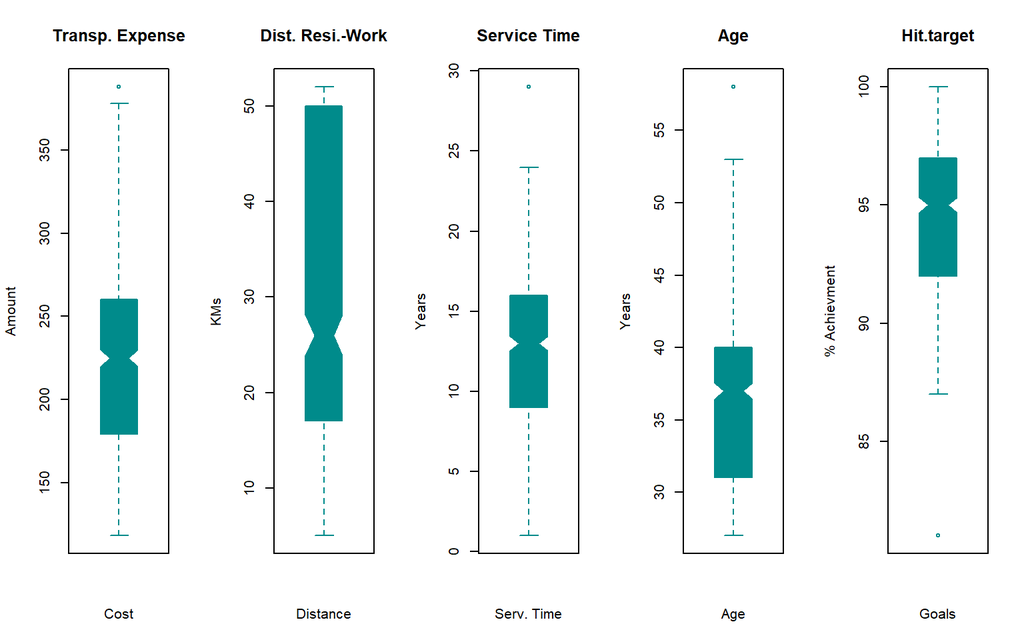

```r
par(mfrow=c(1,5))
boxplot(abs_dataset$Transportation.expense[1:593],
main = "Transp. Expense",
xlab = "Cost",
ylab = "Amount",
col = "darkcyan",
border = "darkcyan",
horizontal = FALSE,
notch = TRUE
)
boxplot(abs_dataset$Distance.from.Residence.to.Work[1:593],
main = "Dist. Resi.-Work",
xlab = "Distance",
ylab = "KMs",
col = "darkcyan",
border = "darkcyan",
horizontal = FALSE,
notch = TRUE
)
boxplot(abs_dataset$Service.time[1:593],
main = "Service Time",
xlab = "Serv. Time",
ylab = "Years",
col = "darkcyan",
border = "darkcyan",
horizontal = FALSE,
notch = TRUE
)
boxplot(abs_dataset$Age[1:593],
main = "Age",
xlab = "Age",
ylab = "Years",
col = "darkcyan",
border = "darkcyan",
horizontal = FALSE,
notch = TRUE
)
boxplot(abs_dataset$Hit.target[1:593],
main = "Hit.target",
xlab = "Goals",
ylab = "% Achievment",
col = "darkcyan",
border = "darkcyan",
horizontal = FALSE,
notch = TRUE
)
```

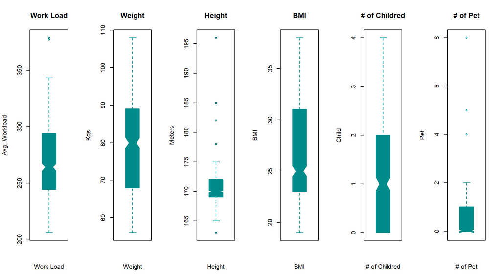

```r
par(mfrow=c(1,6))

boxplot(abs_dataset$Work.load.Average.day[1:593],
main = "Work Load",
xlab = "Work Load",
ylab = "Avg. Workload",
col = "darkcyan",
border = "darkcyan",
horizontal = FALSE,
notch = TRUE
)
boxplot(abs_dataset$Weight[1:593],
main = "Weight",
xlab = "Weight",
ylab = "Kgs",
col = "darkcyan",
border = "darkcyan",
horizontal = FALSE,
notch = TRUE
)
boxplot(abs_dataset$Height[1:593],
main = "Height",
xlab = "Height",
ylab = "Meters",
col = "darkcyan",
border = "darkcyan",
horizontal = FALSE,
notch = TRUE
)
boxplot(abs_dataset$Body.mass.index[1:593],
main = "BMI",
xlab = "BMI",
ylab = "BMI",
col = "darkcyan",
border = "darkcyan",
horizontal = FALSE,
notch = TRUE
)
boxplot(abs_dataset$Son[1:593],
main = "# of Childred",
xlab = "# of Childred",
ylab = "Child",
col = "darkcyan",
border = "darkcyan",
horizontal = FALSE,
notch = TRUE
)
boxplot(abs_dataset$Pet[1:593],
main = "# of Pet",
xlab = "# of Pet",
ylab = "Pet",
col = "darkcyan",
border = "darkcyan",
horizontal = FALSE,
notch = TRUE
)
```

### 3.3.2 Treating Outliers

The initial 5 boxplots show that We have a few outliers in Transport expense, service time, age, and hit.targe. Additionally there are outliers detected in work Load, height and number of pets, in the second group of boxplots.

Refering back to the overview where we see the minimum and maximum value of these variables, we can establish that there is no error in these data points and are actual observations which are deviations from the range in our dataset.

Considering our obejective is to predict if an employee is going to be absent from a workplace, we want to be able to predict this is as many employees as possible. So if a value that lies outisde the range of other values in the training is justfied, the deviation is not extreme and we can expect smiliar deviations from the data outside this set, we can retain the data.

So for outlier detected in **transport expense** , we can keep this outlier as it is not extreme deviation, we expect our real world data to deviate from the range and want our model to be able to predict for such occurances.

Similarly, we will keep outliers in the **percentage of achievement of goals in the (Hit.Target)** and **work load**, as we expect to have employees that might be performing less that others or have higher work load than the rest. We want our model to predict for such kinds of employees as well.

In the case of the outliers detected in the **number of service time and age**, we can assume that there will be very limited employees that will have higher values than the range in the training set. This might be only employees that are in management position which have stayed with company for long time and we don´t expect such employees in out real world data, thus we don´t want our model to train for such unique cases. **However, we will not remove these outliers in number of service time and age, but instead will bin this variables and convert them to categorical variables as in we don’t necessarly need out model to train for each unique case and we assume the category group with have simiar manner.**

For outliers detected in Height, we can keep this records as they are for now as we see that there are no outliers in BMI which combines weight and height (The formula for BMI is weight in kilograms divided by height in meters squared). Accordingly expect high correlation between these values and there is not need for our model to train on weight and height if it uses BMI. And so our model will not be taking into consideration these deviated values from height.

We have three outliers in number of pets owned. Eventhough it is not necessarly an error and employees can have as much as 5 to 8 pets we don’t want our distribution to be affected by such values. We want out model to only capture wether having a pet or not having a pet affects absentieseem and this further justified by the distribution of those who don’t have pets and those which do.

```r
abs_dataset$Pet_encoded<-abs_dataset$Pet
abs_dataset$Pet_encoded[abs_dataset$Pet_encoded > 0] <- 1

abs_dataset[5:15,c('Pet','Pet_encoded')]
```

|  | Pet | Pet_encoded |
| --- | --- | --- |
| 5 | 1 | 1 |
| 7 | 4 | 1 |
| 9 | 0 | 0 |
| 10 | 1 | 1 |
| 11 | 0 | 0 |
| 12 | 0 | 0 |
| 13 | 0 | 0 |
| 14 | 0 | 0 |
| 15 | 0 | 0 |
| 18 | 0 | 0 |

[output cut: 1 more lines]

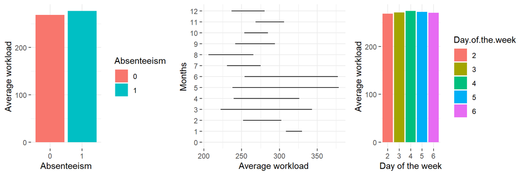

```r
bar_wl_month<-ggplot(abs_dataset, aes(x = abs_dataset$Work.load.Average.day, y = abs_dataset$Month.of.absence), group = abs_dataset$Absenteeism, color = abs_dataset$Absenteeism) +labs(y="Months", x = "Average workload") +
geom_line() + theme_bw() + theme(panel.border = element_blank())

bar_wl_abs<-ggplot(abs_dataset, aes(x = abs_dataset$Absenteeism, y = abs_dataset$Work.load.Average.day, fill=Absenteeism)) +labs(y="Average workload", x = "Absenteeism") +
geom_bar(stat = "summary", fun.y= "mean")+ theme_bw() + theme(panel.border = element_blank())

bar_wl_dow<-ggplot(abs_dataset, aes(x = abs_dataset$Day.of.the.week, y = abs_dataset$Work.load.Average.day, fill=Day.of.the.week)) + labs(y="Average workload", x = "Day of the week") +
geom_bar(stat = "summary", fun.y= "mean") + theme_bw() + theme(panel.border = element_blank())

gridExtra::grid.arrange(bar_wl_abs, bar_wl_month, bar_wl_dow,ncol=3)
```

the plot above compares how work load relates to variables such as month of absence and what the average work load for those that were absent and were not. There seems to be no clear correlation as the average workload for those with long absentees and those with not is similar. And there is no trend in month of absense and average workload

## 3.4 Advanced Factorization

Following the handeling out outliers, further factorization through binning can be done on variables which have levels of detail that we don’t need our model to train on and capture. In this dataset we will bin the variables **Age**, **Years of service**, **distance from residence to work**, and **transport cost**.

To check that our binning is actually improving our model prediction we will keep the original numeric variable and we will create a new factor variable for each of these attributes.

- **Age** We can bin our employees into
  - 18 to 25 : very young employees
  - 26 to 35 : young employees
  - 36 to 45 : middle age employees
  - Above 45 : old age employess

```r
abs_dataset$age_bin <-.bincode(abs_dataset$Age, c(18, 25, 35,45,100))
abs_dataset$age_bin<- recode(abs_dataset$age_bin,`1`="Very Young Employee",`2`="Young Employee",`3`="Middle Age Employee",`4`="Old Age Employee")
abs_dataset$age_bin<-as.factor(abs_dataset$age_bin)
abs_dataset[5:15,c('Age','age_bin')]
```

|  | Age | age_bin |
| --- | --- | --- |
| 5 | 33 | Young Employee |
| 7 | 28 | Young Employee |
| 9 | 34 | Young Employee |
| 10 | 37 | Middle Age Employee |
| 11 | 36 | Middle Age Employee |
| 12 | 36 | Middle Age Employee |
| 13 | 36 | Middle Age Employee |
| 14 | 38 | Middle Age Employee |
| 15 | 38 | Middle Age Employee |
| 18 | 38 | Middle Age Employee |

[output cut: 1 more lines]

- **Service Time** We can bin our employees into 4 categories based on the quantiles, which will create bins automatically using the dataset distribution.

```r
service_time_bins<-bins.quantiles(abs_dataset$Service.time, 4, 4, verbose = FALSE)
service_time_bins$binc
```

```
##   [1, 9] [10, 13] [14, 16] [17, 29]
##      200      239      127      174
```

```r
#[1, 9] [10, 13] [14, 16] [17, 29] we will use this range to create binned variable.

abs_dataset$service.time_bin <-.bincode(abs_dataset$Service.time, c(0, 10, 14,17,30),FALSE, TRUE)
abs_dataset$service.time_bin<- recode(abs_dataset$service.time_bin,`1`="1-9 yrs",`2`="10 to 13 yrs",`3`="14 to 16 yrs",`4`="17 to 29 yrs")

abs_dataset$service.time_bin<-as.factor(abs_dataset$service.time_bin)
abs_dataset[100:105,c('Service.time','service.time_bin')] #viewing binned data
```

|  | Service.time | service.time_bin |
| --- | --- | --- |
| 128 | 10 | 10 to 13 yrs |
| 129 | 10 | 10 to 13 yrs |
| 130 | 9 | 1-9 yrs |
| 131 | 13 | 10 to 13 yrs |
| 137 | 13 | 10 to 13 yrs |
| 138 | 7 | 1-9 yrs |

- **Distance from residence to work**, and **Transportation Expense** The two variables will be binned as follows: Transportation Expense:
  - 100 to 199 : Cheap
  - 200 to 299 : Normal
  - Above 300: Expensive

```r
abs_dataset$Transportation.expense_bin <-.bincode(abs_dataset$Transportation.expense, c(100, 200, 300,2000), FALSE, TRUE)
abs_dataset$Transportation.expense_bin<- recode(abs_dataset$Transportation.expense_bin, `1`="Cheap",`2`="Normal",`3`="Very Expensive")

abs_dataset$Transportation.expense_bin<-as.factor(abs_dataset$Transportation.expense_bin)
abs_dataset[210:215,c('Transportation.expense','Transportation.expense_bin')]
```

|  | Transportation.expense | Transportation.expense_bin |
| --- | --- | --- |
| 271 | 179 | Cheap |
| 272 | 179 | Cheap |
| 273 | 289 | Normal |
| 274 | 235 | Normal |
| 275 | 246 | Normal |
| 276 | 291 | Normal |

```r
distance_bins<-bins.quantiles(abs_dataset$Distance.from.Residence.to.Work, 4, 4, verbose = FALSE)
distance_bins$binc
```

```
##  [5, 16] [17, 26] [27, 50] [51, 52]
##      194      236      166      144
```

```r
#[5, 16] [17, 26] [27, 50] [51, 52]  we will use this range to create binned variable.
abs_dataset$Distance.Resi.to.Work_bin <-.bincode(abs_dataset$Distance.from.Residence.to.Work, c(5, 17, 27,51, 53), FALSE, TRUE)
abs_dataset$Distance.Resi.to.Work_bin <- recode(abs_dataset$Distance.Resi.to.Work_bin,`1`="Close",`2`="Average Distance",`3`="Far",`4`="Very Far")
abs_dataset[100:105,c('Distance.from.Residence.to.Work','Distance.Resi.to.Work_bin')] #viewing binned data
```

|  | Distance.from.Residence.to.Work | Distance.Resi.to.Work_bin |
| --- | --- | --- |
| 128 | 10 | Close |
| 129 | 10 | Close |
| 130 | 26 | Average Distance |
| 131 | 36 | Far |
| 137 | 36 | Far |
| 138 | 42 | Far |

### 3.4.1 Correlation Between Exlanatory Variables

Below we explore further to check correlation between linear variables using Pearson correlation test to establish statistical evidence for taking action on handeling these attribues differently.

```r
cor.test(abs_dataset$Height, abs_dataset$Body.mass.index, method="pearson")
```

```
##
##  Pearson's product-moment correlation
##
## data:  abs_dataset$Height and abs_dataset$Body.mass.index
## t = -3.3128, df = 738, p-value = 0.0009687
## alternative hypothesis: true correlation is not equal to 0
## 95 percent confidence interval:
##  -0.1914496 -0.0494088
## sample estimates:
##        cor
## -0.1210488
```

```r
cor.test(abs_dataset$Weight, abs_dataset$Body.mass.index, method="pearson")
```

```
##
##  Pearson's product-moment correlation
##
## data:  abs_dataset$Weight and abs_dataset$Body.mass.index
## t = 57.482, df = 738, p-value < 2.2e-16
## alternative hypothesis: true correlation is not equal to 0
## 95 percent confidence interval:
##  0.8900415 0.9164702
## sample estimates:
##       cor
## 0.9041169
```

The correlation test above using the Pearson method for both **Weight** and **Height** with **Body.mass.index** as expected resulted in values very less than the significance level alpha = 0.05.

```r
cor.test(abs_dataset$Transportation.expense, abs_dataset$Distance.from.Residence.to.Work, method="pearson")
```

```
##
##  Pearson's product-moment correlation
##
## data:  abs_dataset$Transportation.expense and abs_dataset$Distance.from.Residence.to.Work
## t = 7.3807, df = 738, p-value = 4.253e-13
## alternative hypothesis: true correlation is not equal to 0
## 95 percent confidence interval:
##  0.1937736 0.3280553
## sample estimates:
##       cor
## 0.2621831
```

## 3.5 Preparing Cleaned Train and Test

```r
colnames(abs_dataset)[which(names(abs_dataset) == "Son")] <- "Number_Children"
#Renaming "Son" Attribute to more accurate name

data.frame(Variable = names(abs_dataset),
           Class = sapply(abs_dataset, class),
           First_values = sapply(abs_dataset, function(x) paste0(head(x),  collapse = ", ")),
           row.names = NULL) %>% kable()
```

[output not shown]

```r
abs_dataset$ID.Worker<- NULL
abs_dataset$Weight<- NULL
abs_dataset$Height<- NULL
```

### 3.5.1 Train and Test Split

```r
training1 <- abs_dataset[1:593,]
test1 <- abs_dataset[594:740,]
```

**Note: The test1 dataset is not going to be used until the file model to predict the unknow target variable."

# 4 Feature Selection

### 4.0.1 Training and Validation

To be able to evaluate our model we will split the training dataset into training and validation, and use the validation set as if it is a test set. This way we can compare the accuracy of our model before and after feature selection.

We will use the same proportion as the original test set that is 24% of the training set. We will make this split random. We will create this for the cleaned training dataset and the original training dataset.

```r
initial_training_size <- floor(0.76 * nrow(abs_trainset_df))
cleaned_training1_size<- floor(0.76 * nrow(training1))

set.seed(123) #so we have the same random pick from the inital and cleaned
train_init. <- sample(seq_len(nrow(abs_trainset_df)), size = initial_training_size)
set.seed(123)
train_clean. <- sample(seq_len(nrow(training1)), size = cleaned_training1_size)

train_initial <- abs_trainset_df[train_init., ]
validation_initial<- abs_trainset_df[-train_init., ] #what wasn't in training will be validation

train_cleaned <- training1[train_clean., ]
validation_cleaned<- training1[-train_clean., ]
```

## 4.1 Baseline Model

We will fit a general linear model that will be used to compare our model before and after data cleaning and feature filtering.

```r
library(caret)
train_initial$Absenteeism <- factor(train_initial$Absenteeism, levels = c("0", "1"), labels = c("Not Absent", "Absent"))

validation_initial$Absenteeism <- factor(validation_initial$Absenteeism, levels = c("0", "1"), labels = c("Not Absent", "Absent"))



  set.seed(123)
  # Create a training control configuration that applies a 10-fold cross validation
  train_control_config <- trainControl(method = "repeatedcv",
                                       number = 10,
                                       repeats = 1,
                                       returnResamp = "all")

  # Fit a glm model to the input training data
  initial.lm.mod <- train(Absenteeism ~ . -ID,
                       data = train_initial,
                       method = "glm",
                       metric = "Accuracy",
                       preProc = c("center", "scale"),
                       trControl=train_control_config)
```

### 4.1.1 Baseline Model Evaluation

We will fit a general linear model that will be used to compare our model before and after data cleaning and feature filtering.

```r
# Predict
initial.lm.mod.pred <- predict(initial.lm.mod, validation_initial[,-which(names(validation_initial) == "Absenteeism")])
```

```r
# Plot the confusion matrix
cm_initial <- confusionMatrix(initial.lm.mod.pred, validation_initial$Absenteeism, positive = "Not Absent")
print(cm_initial)
```

```
## Confusion Matrix and Statistics
##
##             Reference
## Prediction   Not Absent Absent
##   Not Absent         76     15
##   Absent             17     35
##
##                Accuracy : 0.7762
##                  95% CI : (0.699, 0.8416)
##     No Information Rate : 0.6503
##     P-Value [Acc > NIR] : 0.000769
##
##                   Kappa : 0.5125
##
##  Mcnemar's Test P-Value : 0.859684
##
##             Sensitivity : 0.8172
##             Specificity : 0.7000
##          Pos Pred Value : 0.8352
##          Neg Pred Value : 0.6731
##              Prevalence : 0.6503
##          Detection Rate : 0.5315
##    Detection Prevalence : 0.6364
##       Balanced Accuracy : 0.7586
##
##        'Positive' Class : Not Absent
##
```

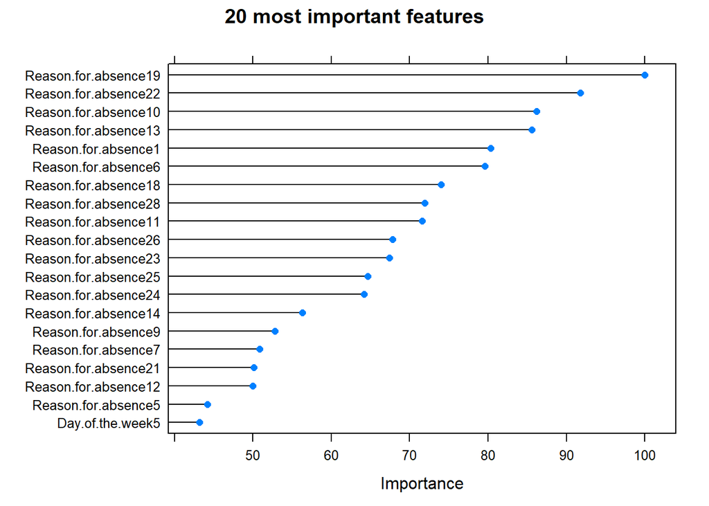

```r
# Plot the 20 most important features
plot(varImp(initial.lm.mod),top= 20, main = "20 most important features")
```

## 4.2 Chi-Square Test Initial

```r
library(FSelector)

weights<- data.frame(chi.squared(Absenteeism~., train_cleaned[,-which(names(train_cleaned) == "ID")])) # Chi-squared computation
weights$feature <- rownames(weights)
weights[order(weights$attr_importance, decreasing = TRUE),] # Order the features by their weights
```

|  | attr_importance | feature |
| --- | --- | --- |
| Reason.for.absence | 0.75459304 | Reason.for.absence |
| Transportation.expense | 0.23562972 | Transportation.expense |
| Day.of.the.week | 0.23457914 | Day.of.the.week |
| Month.of.absence | 0.22725787 | Month.of.absence |
| service.time_bin | 0.22146891 | service.time_bin |
| Transportation.expense_bin | 0.21283419 | Transportation.expense_bin |
| Disciplinary.failure | 0.18320229 | Disciplinary.failure |
| Distance.Resi.to.Work_bin | 0.17869798 | Distance.Resi.to.Work_bin |
| Social.smoker | 0.10963446 | Social.smoker |
| Seasons | 0.10710400 | Seasons |

[output cut: 12 more lines]

```r
chi_squared_features <- weights$feature[weights$attr_importance > 0.1]
```

### 4.2.1 Evaluation Chi-Square Round 1

Here we valuate the impact of the feature selection through the validation set. We use the chi-squared-filtered training set into the linear model.

```r
chi_squared.lm.mod <- train(Absenteeism ~ ., data = train_cleaned[append(chi_squared_features, "Absenteeism")],
               method = "glm",
               metric = "Accuracy",
               preProc = c("center", "scale"),
               trControl=train_control_config)


chi_squared.lm.mod.pred <- predict(chi_squared.lm.mod, validation_cleaned[,-!names(validation_cleaned) %in% c("Absenteeism", "ID")])

cm <- confusionMatrix(chi_squared.lm.mod.pred, validation_cleaned$Absenteeism, positive = "0")
print(cm)
```

```
## Confusion Matrix and Statistics
##
##           Reference
## Prediction  0  1
##          0 80 12
##          1 13 38
##
##                Accuracy : 0.8252
##                  95% CI : (0.7528, 0.8836)
##     No Information Rate : 0.6503
##     P-Value [Acc > NIR] : 2.981e-06
##
##                   Kappa : 0.6174
##
##  Mcnemar's Test P-Value : 1
##
##             Sensitivity : 0.8602
##             Specificity : 0.7600
##          Pos Pred Value : 0.8696
##          Neg Pred Value : 0.7451
##              Prevalence : 0.6503
##          Detection Rate : 0.5594
##    Detection Prevalence : 0.6434
##       Balanced Accuracy : 0.8101
##
##        'Positive' Class : 0
##
```

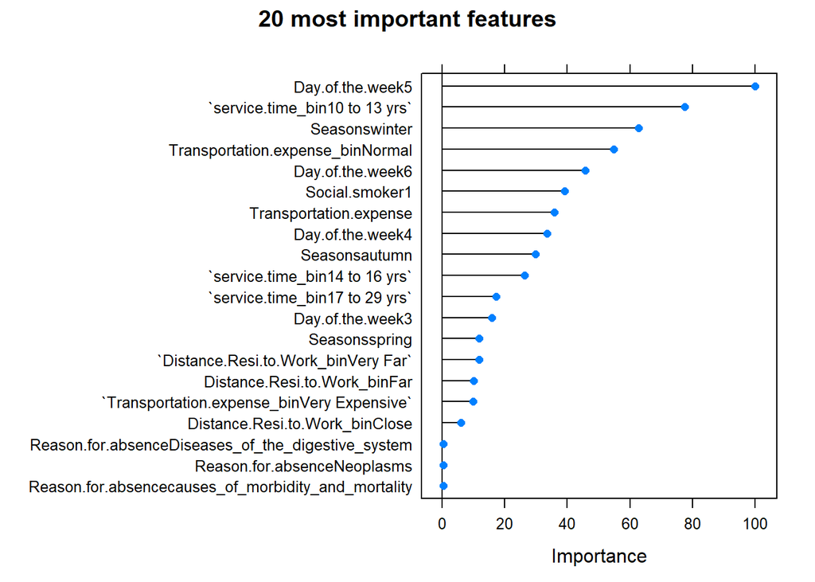

```r
plot(varImp(chi_squared.lm.mod),top= 20, main = "20 most important features")
```

From the Chi- square variable importance we can see that the variable we binned for **transportation expense** and **Distance from residence to work** has more importance than the original variable. Thus, we can avoid high correlation by removing the original vairables and run Chi Square again.

##Chi-Square Test Round 2

Under this section we are going to remove the variable mentioned above from the cleaned in both the train and test. Then Run the validation split again.

**Round 2 - Train and Test Update**

```r
abs_dataset$Transportation.expense<-NULL
abs_dataset$Distance.from.Residence.to.Work<-NULL
abs_dataset$Service.time<- NULL





training2 <- abs_dataset[1:593,]
test2 <- abs_dataset[594:740,]

#Second Training Set
train_size<- floor(0.76 * nrow(training1))

set.seed(123)
train_clean.2 <- sample(seq_len(nrow(training2)), size = train_size)

train_cleaned2 <- training2[train_clean.2, ]
validation_cleaned2<- training2[-train_clean.2, ]
```

Now we will run the Chi-Square Test again with new Training and validation dataset.

```r
library(FSelector)

weights<- data.frame(chi.squared(Absenteeism~., train_cleaned2[,names(train_cleaned2) != "ID"])) # Chi-squared computation
weights$feature <- rownames(weights)
weights[order(weights$attr_importance, decreasing = TRUE),] # Order the features by their weights
```

|  | attr_importance | feature |
| --- | --- | --- |
| Reason.for.absence | 0.75459304 | Reason.for.absence |
| Day.of.the.week | 0.23457914 | Day.of.the.week |
| Month.of.absence | 0.22725787 | Month.of.absence |
| service.time_bin | 0.22146891 | service.time_bin |
| Transportation.expense_bin | 0.21283419 | Transportation.expense_bin |
| Disciplinary.failure | 0.18320229 | Disciplinary.failure |
| Distance.Resi.to.Work_bin | 0.17869798 | Distance.Resi.to.Work_bin |
| Social.smoker | 0.10963446 | Social.smoker |
| Seasons | 0.10710400 | Seasons |
| Education | 0.09961246 | Education |

[output cut: 9 more lines]

```r
chi_squared_features <- weights$feature[weights$attr_importance > 0.1]
```

### 4.2.2 Evaluation Chi-Square Round 2

```r
chi_squared.lm.mod <- train(Absenteeism ~ ., data = train_cleaned2[append(chi_squared_features, "Absenteeism")],
               method = "glm",
               metric = "Accuracy",
               preProc = c("center", "scale"),
               trControl=train_control_config)


chi_squared.lm.mod.pred <- predict(chi_squared.lm.mod, validation_cleaned2[,!names(validation_cleaned2) %in% c("Absenteeism", "ID")])

cm <- confusionMatrix(chi_squared.lm.mod.pred, validation_cleaned2$Absenteeism, positive = "0")
print(cm)
```

```
## Confusion Matrix and Statistics
##
##           Reference
## Prediction  0  1
##          0 79 12
##          1 14 38
##
##                Accuracy : 0.8182
##                  95% CI : (0.7451, 0.8777)
##     No Information Rate : 0.6503
##     P-Value [Acc > NIR] : 7.491e-06
##
##                   Kappa : 0.6039
##
##  Mcnemar's Test P-Value : 0.8445
##
##             Sensitivity : 0.8495
##             Specificity : 0.7600
##          Pos Pred Value : 0.8681
##          Neg Pred Value : 0.7308
##              Prevalence : 0.6503
##          Detection Rate : 0.5524
##    Detection Prevalence : 0.6364
##       Balanced Accuracy : 0.8047
##
##        'Positive' Class : 0
##
```

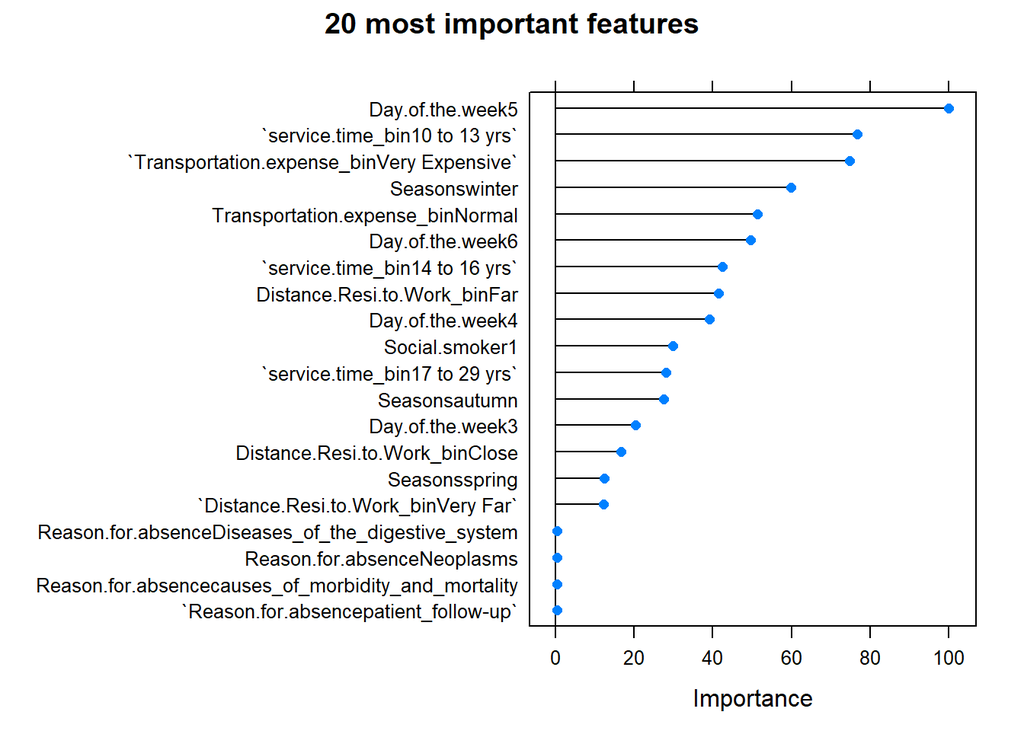

```r
plot(varImp(chi_squared.lm.mod),top= 20, main = "20 most important features")
```

## 4.3 Information Gain Selection

We will try now to use another feature selection method and see if it has improved accuracy.

```r
weights<- data.frame(information.gain(Absenteeism~., train_cleaned[,names(train_cleaned) != "ID"]))
weights$feature <- rownames(weights)
weights[order(weights$attr_importance, decreasing = TRUE),]
```

|  | attr_importance | feature |
| --- | --- | --- |
| Reason.for.absence | 0.335728427 | Reason.for.absence |
| Day.of.the.week | 0.027544734 | Day.of.the.week |
| Month.of.absence | 0.027036317 | Month.of.absence |
| Transportation.expense | 0.027026945 | Transportation.expense |
| Disciplinary.failure | 0.025813399 | Disciplinary.failure |
| service.time_bin | 0.024487651 | service.time_bin |
| Transportation.expense_bin | 0.021884253 | Transportation.expense_bin |
| Distance.Resi.to.Work_bin | 0.015969851 | Distance.Resi.to.Work_bin |
| Social.smoker | 0.005788508 | Social.smoker |
| Education | 0.005739007 | Education |

[output cut: 12 more lines]

```r
information_gain_features <- weights$feature[weights$attr_importance > 0.015]
```

##### 4.3.0.0.1 Evaluation Information Gain

Let’s experiment now with Information Gain Selection. Making use of the `FSelector` package (or other you choice), rank the features according to their Information Gain and filter those which you consider, according to the IG value.

```r
weights<- data.frame(information.gain(Absenteeism~., train_cleaned[,names(train_cleaned) != "ID"]))
weights$feature <- rownames(weights)
weights[order(weights$attr_importance, decreasing = TRUE),]
```

|  | attr_importance | feature |
| --- | --- | --- |
| Reason.for.absence | 0.335728427 | Reason.for.absence |
| Day.of.the.week | 0.027544734 | Day.of.the.week |
| Month.of.absence | 0.027036317 | Month.of.absence |
| Transportation.expense | 0.027026945 | Transportation.expense |
| Disciplinary.failure | 0.025813399 | Disciplinary.failure |
| service.time_bin | 0.024487651 | service.time_bin |
| Transportation.expense_bin | 0.021884253 | Transportation.expense_bin |
| Distance.Resi.to.Work_bin | 0.015969851 | Distance.Resi.to.Work_bin |
| Social.smoker | 0.005788508 | Social.smoker |
| Education | 0.005739007 | Education |

[output cut: 12 more lines]

```r
information_gain_features <- weights$feature[weights$attr_importance > 0.015]
```

##### 4.3.0.0.2 Information Gain Evaluation I

Evaluate the impact of the IG selection in the model performance using validation set.

```r
ig.lm.mod <- train(Absenteeism ~ ., data = train_cleaned[append(information_gain_features, "Absenteeism")],
               method = "glm",
               metric = "Accuracy",
               preProc = c("center", "scale"),
               trControl=train_control_config)
ig.lm.mod.pred <- predict(ig.lm.mod, validation_cleaned[,-which(names(validation_cleaned) == "Absenteeism")])
cm <- confusionMatrix(ig.lm.mod.pred, validation_cleaned$Absenteeism, positive = "0")
print(cm)
```

```
## Confusion Matrix and Statistics
##
##           Reference
## Prediction  0  1
##          0 78 12
##          1 15 38
##
##                Accuracy : 0.8112
##                  95% CI : (0.7373, 0.8717)
##     No Information Rate : 0.6503
##     P-Value [Acc > NIR] : 1.8e-05
##
##                   Kappa : 0.5905
##
##  Mcnemar's Test P-Value : 0.7003
##
##             Sensitivity : 0.8387
##             Specificity : 0.7600
##          Pos Pred Value : 0.8667
##          Neg Pred Value : 0.7170
##              Prevalence : 0.6503
##          Detection Rate : 0.5455
##    Detection Prevalence : 0.6294
##       Balanced Accuracy : 0.7994
##
##        'Positive' Class : 0
##
```

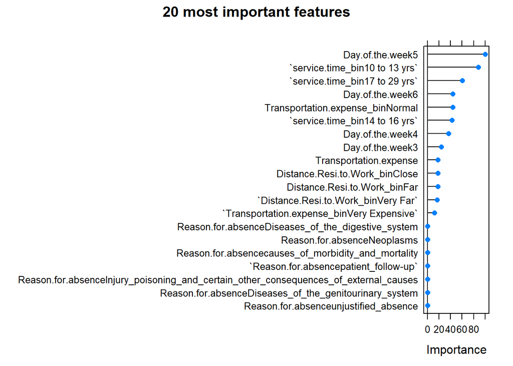

```r
plot(varImp(ig.lm.mod),top= 20, main = "20 most important features")
```

There is no improvment in accuracy of this feature selector than the chi-squared.

##### 4.3.0.0.3 Evaluation Information Gain - With Second II

We will try this again the second time with the train_cleaned2 again.

```r
weights<- data.frame(information.gain(Absenteeism~., train_cleaned2[,names(train_cleaned2) != "ID"]))
weights$feature <- rownames(weights)
weights[order(weights$attr_importance, decreasing = TRUE),]
```

|  | attr_importance | feature |
| --- | --- | --- |
| Reason.for.absence | 0.335728427 | Reason.for.absence |
| Day.of.the.week | 0.027544734 | Day.of.the.week |
| Month.of.absence | 0.027036317 | Month.of.absence |
| Disciplinary.failure | 0.025813399 | Disciplinary.failure |
| service.time_bin | 0.024487651 | service.time_bin |
| Transportation.expense_bin | 0.021884253 | Transportation.expense_bin |
| Distance.Resi.to.Work_bin | 0.015969851 | Distance.Resi.to.Work_bin |
| Social.smoker | 0.005788508 | Social.smoker |
| Education | 0.005739007 | Education |
| Seasons | 0.005734043 | Seasons |

[output cut: 9 more lines]

```r
information_gain_features <- weights$feature[weights$attr_importance > 0.015]
```

##### 4.3.0.0.4 Information Gain Evaluation - For Second Train Set

Evaluate the impact of the IG selection in the model performance

```r
ig.lm.mod <- train(Absenteeism ~ ., data = train_cleaned2[append(information_gain_features, "Absenteeism")],
               method = "glm",
               metric = "Accuracy",
               preProc = c("center", "scale"),
               trControl=train_control_config)
ig.lm.mod.pred <- predict(ig.lm.mod, validation_cleaned2[,-which(names(validation_cleaned2) == "Absenteeism")])
cm <- confusionMatrix(ig.lm.mod.pred, validation_cleaned2$Absenteeism, positive = "0")
print(cm)
```

```
## Confusion Matrix and Statistics
##
##           Reference
## Prediction  0  1
##          0 78 12
##          1 15 38
##
##                Accuracy : 0.8112
##                  95% CI : (0.7373, 0.8717)
##     No Information Rate : 0.6503
##     P-Value [Acc > NIR] : 1.8e-05
##
##                   Kappa : 0.5905
##
##  Mcnemar's Test P-Value : 0.7003
##
##             Sensitivity : 0.8387
##             Specificity : 0.7600
##          Pos Pred Value : 0.8667
##          Neg Pred Value : 0.7170
##              Prevalence : 0.6503
##          Detection Rate : 0.5455
##    Detection Prevalence : 0.6294
##       Balanced Accuracy : 0.7994
##
##        'Positive' Class : 0
##
```

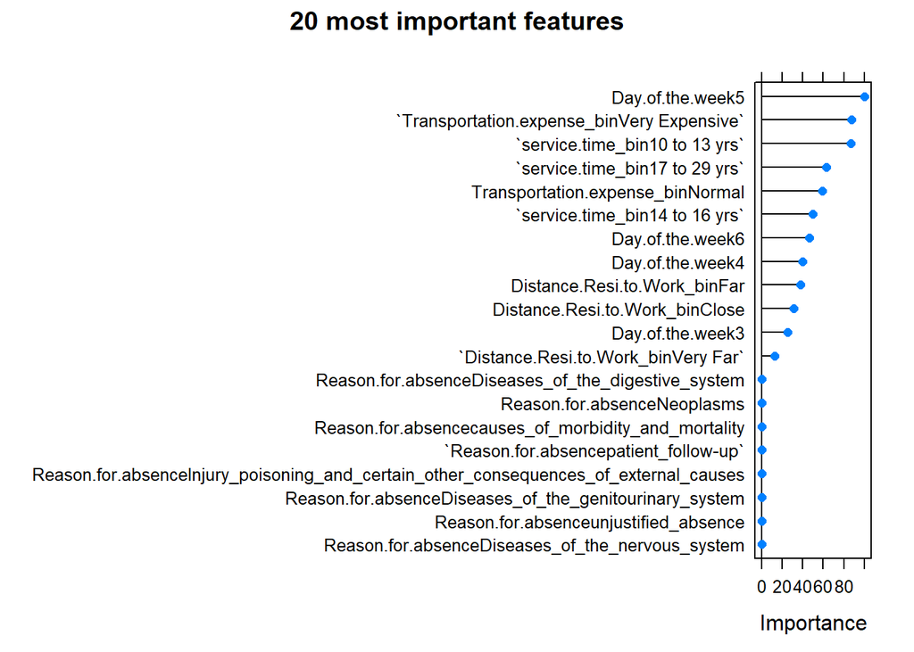

```r
plot(varImp(ig.lm.mod),top= 20, main = "20 most important features")
```

Following the second round again the accuracy didn’t show any improvments.

## 4.4 Chi Square Vs Information Gain Selection

```r
## Chi Vs Info
chi_training <- train_cleaned[append(chi_squared_features, "Absenteeism")]
chi_validation <- validation_cleaned[append(chi_squared_features, "Absenteeism")]


chi_training2 <- train_cleaned2[append(chi_squared_features, "Absenteeism")]
chi_validation2 <- validation_cleaned2[append(chi_squared_features, "Absenteeism")]
```

## 4.5 Wrapper Method

Wrapper methods consider the selection of a set of features as a search problem, where different combinations are prepared, evaluated and compared to other combinations. A predictive model us used to evaluate a combination of features and assign a score based on model accuracy. We will use forward and backward stepwise method to improve our features.

#### 4.5.0.1 Backward Stepwise

Now, it is time to select what is the best possible compromise between the number of predictors and the results obtained. Firstly, we try backward stepwise.

We got error “At least one of the class levels is not a valid R variable name;” so we change the levels for target variable.

```r
library(caret)
levels(train_cleaned$Absenteeism)[levels(train_cleaned$Absenteeism)=="0"]<- "Not_Absent"
levels(train_cleaned$Absenteeism)[levels(train_cleaned$Absenteeism)=="1"]<- "Absent"

levels(validation_cleaned$Absenteeism)[levels(validation_cleaned$Absenteeism)=="0"]<- "Not_Absent"
levels(validation_cleaned$Absenteeism)[levels(validation_cleaned$Absenteeism)=="1"]<- "Absent"



levels(train_cleaned2$Absenteeism)[levels(train_cleaned2$Absenteeism)=="0"]<- "Not_Absent"
levels(train_cleaned2$Absenteeism)[levels(train_cleaned$Absenteeism)=="1"]<- "Absent"

levels(validation_cleaned2$Absenteeism)[levels(validation_cleaned2$Absenteeism)=="0"]<- "Not_Absent"
levels(validation_cleaned2$Absenteeism)[levels(validation_cleaned2$Absenteeism)=="1"]<- "Absent"



levels(chi_training$Absenteeism)[levels(chi_training$Absenteeism)=="0"]<- "Not_Absent"
levels(chi_training$Absenteeism)[levels(chi_training$Absenteeism)=="1"]<- "Absent"

levels(chi_validation$Absenteeism)[levels(chi_validation$Absenteeism)=="0"]<- "Not_Absent"
levels(chi_validation$Absenteeism)[levels(chi_validation$Absenteeism)=="1"]<- "Absent"
```

**NOTE THE FOLLOWING BACKWARD STEPWISE CODE TAKES LONG TO LOAD**

```r
train_control_config_4_stepwise <- trainControl(method = "none", classProbs = TRUE)

backward.lm.mod <- train(Absenteeism ~ ., data = train_cleaned[,names(train_cleaned) != "ID"],
               method = "glmStepAIC",
               direction = "backward",
               trace = FALSE,
               metric = "Accuracy",
               trControl=train_control_config_4_stepwise)
```

```r
paste("Features Selected" ,backward.lm.mod$finalModel$formula[3])
```

```
## [1] "Features Selected Reason.for.absenceNeoplasms + Reason.for.absenceDiseases_of_the_blood + Reason.for.absenceEndocrine_and_metabolic_diseases + Reason.for.absenceDiseases_of_the_nervous_system + Reason.for.absenceDiseases_of_the_eye_and_adnexa + Reason.for.absenceDiseases_of_the_ear_and_masto…
```

Evaluate the selected model

```r
backward.lm.mod.pred <- predict(backward.lm.mod, validation_cleaned[,-which(names(validation_cleaned) == "Absenteeism")])

cm <- confusionMatrix(backward.lm.mod.pred, validation_cleaned$Absenteeism, positive = "Not_Absent")
print(cm)
```

```
## Confusion Matrix and Statistics
##
##             Reference
## Prediction   Not_Absent Absent
##   Not_Absent         78     18
##   Absent             15     32
##
##                Accuracy : 0.7692
##                  95% CI : (0.6915, 0.8355)
##     No Information Rate : 0.6503
##     P-Value [Acc > NIR] : 0.001449
##
##                   Kappa : 0.4854
##
##  Mcnemar's Test P-Value : 0.727724
##
##             Sensitivity : 0.8387
##             Specificity : 0.6400
##          Pos Pred Value : 0.8125
##          Neg Pred Value : 0.6809
##              Prevalence : 0.6503
##          Detection Rate : 0.5455
##    Detection Prevalence : 0.6713
##       Balanced Accuracy : 0.7394
##
##        'Positive' Class : Not_Absent
##
```

This model didn’t improve the performance of our lm.mod model. Below we will try this algorithm on the just the selected attributes of chi-square instead of the whole train data set and see if there is any improvment.

```r
train_control_config_4_stepwise <- trainControl(method = "none", classProbs = TRUE)

backward.lm.mod <- train(Absenteeism ~ ., data = chi_training[,names(chi_training) != "ID"],
               method = "glmStepAIC",
               direction = "backward",
               trace = FALSE,
               metric = "Accuracy",
               trControl=train_control_config_4_stepwise)
paste("Features Selected" ,backward.lm.mod$finalModel$formula[3])
```

```
## [1] "Features Selected Reason.for.absenceNeoplasms + Reason.for.absenceDiseases_of_the_blood + Reason.for.absenceEndocrine_and_metabolic_diseases + Reason.for.absenceDiseases_of_the_nervous_system + Reason.for.absenceDiseases_of_the_eye_and_adnexa + Reason.for.absenceDiseases_of_the_ear_and_masto…
```

```r
backward.lm.mod.pred <- predict(backward.lm.mod, chi_validation[,-which(names(chi_validation) == "Absenteeism")])

cm <- confusionMatrix(backward.lm.mod.pred, chi_validation$Absenteeism, positive = "Not_Absent")
print(cm)
```

```
## Confusion Matrix and Statistics
##
##             Reference
## Prediction   Not_Absent Absent
##   Not_Absent         78     11
##   Absent             15     39
##
##                Accuracy : 0.8182
##                  95% CI : (0.7451, 0.8777)
##     No Information Rate : 0.6503
##     P-Value [Acc > NIR] : 7.491e-06
##
##                   Kappa : 0.6075
##
##  Mcnemar's Test P-Value : 0.5563
##
##             Sensitivity : 0.8387
##             Specificity : 0.7800
##          Pos Pred Value : 0.8764
##          Neg Pred Value : 0.7222
##              Prevalence : 0.6503
##          Detection Rate : 0.5455
##    Detection Prevalence : 0.6224
##       Balanced Accuracy : 0.8094
##
##        'Positive' Class : Not_Absent
##
```

No improved accuracy with the backward stepwise.

#### 4.5.0.2 Forward Stepwise

Getting errors with unexpected value. Suspecting that this error is coming from variables that have numeric values.

```r
#train_control_config_4_stepwise <- trainControl(method = "none", classProbs = TRUE, allowParallel = TRUE)

#forward.lm.mod <- train(Absenteeism ~ ., data = chi_training,
                                      # method = "glmStepAIC",
                                       #direction = "forward",
                                       #trace=FALSE,
                                       #metric = "Accuracy",
                                       #trControl=train_control_config_4_stepwise)
```

```r
#paste("Features Selected" ,forward.lm.mod$finalModel$formula[3])
```

```r
#forward.lm.mod.pred <- predict(forward.lm.mod, chi_validation[,-which(names(chi_validation) == "Absenteeism")])

#cm <- confusionMatrix(forward.lm.mod.pred, chi_validation$Absenteeism, positive = "Not_Absent")
#print(cm)
```

This process is not able to further improve our feautre. So, we will take the chi_training.

### 4.5.1 Ridge

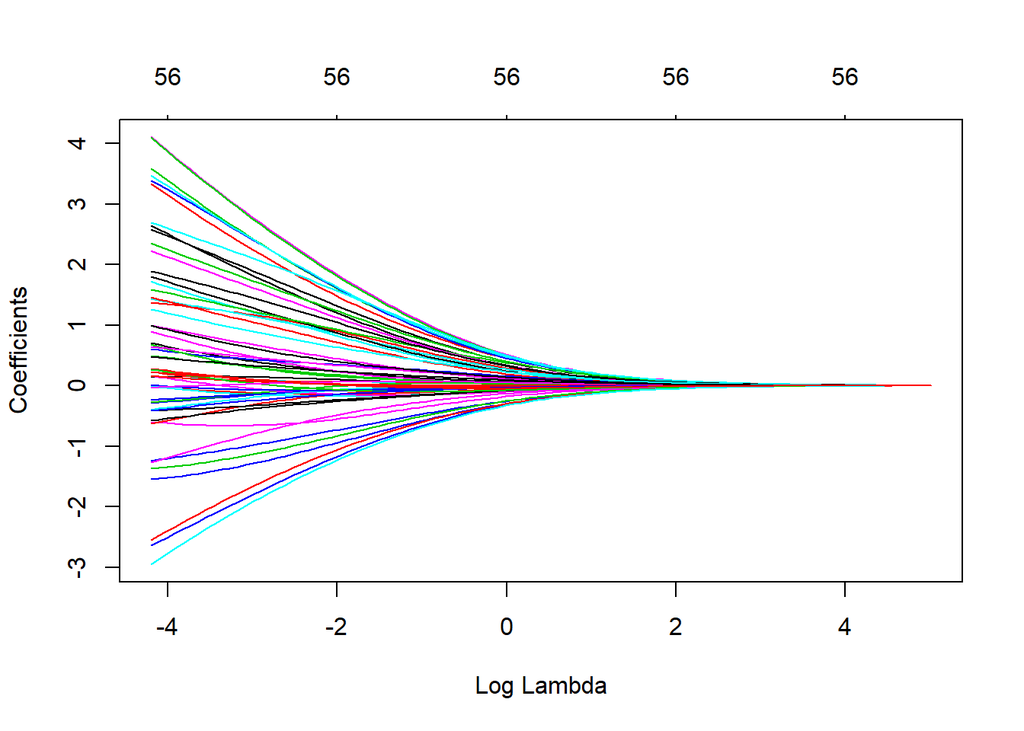

```r
lambdas <- 10^seq(-2, 1, by = .1)

ridge.mod <- train(Absenteeism ~ ., data = chi_training2[,names(chi_training2) != "ID"],
               method = "glmnet",
               metric = "Accuracy",
               tuneGrid = expand.grid(alpha = 0, lambda = lambdas))

plot(ridge.mod$finalModel, xvar = "lambda")
```

```r
bestlam <- ridge.mod$bestTune['lambda']
paste("Best Lambda value from CV=", bestlam)
```

```
## [1] "Best Lambda value from CV= 0.0125892541179417"
```

```r
ridge.pred= predict(ridge.mod, s=bestlam, chi_validation2[,-which(names(chi_validation2) == "Absenteeism")])
cm <- confusionMatrix(ridge.pred, chi_validation2$Absenteeism, positive = "0")
print(cm)
```

```
## Confusion Matrix and Statistics
##
##           Reference
## Prediction  0  1
##          0 78 11
##          1 15 39
##
##                Accuracy : 0.8182
##                  95% CI : (0.7451, 0.8777)
##     No Information Rate : 0.6503
##     P-Value [Acc > NIR] : 7.491e-06
##
##                   Kappa : 0.6075
##
##  Mcnemar's Test P-Value : 0.5563
##
##             Sensitivity : 0.8387
##             Specificity : 0.7800
##          Pos Pred Value : 0.8764
##          Neg Pred Value : 0.7222
##              Prevalence : 0.6503
##          Detection Rate : 0.5455
##    Detection Prevalence : 0.6224
##       Balanced Accuracy : 0.8094
##
##        'Positive' Class : 0
##
```

### 4.5.2 Lasso Regresion

Lasso remove unimportant features by setting their coefficient to zero and at the end we will check the accuracy of this model on validation dataset and the list of variable that were given coefficients higher than zero.

```r
lasso.mod <- train(Absenteeism ~ ., data = chi_training2[, names(chi_training2) != "ID"],
               method = "glmnet",
               metric = "Accuracy",
               tuneGrid = expand.grid(alpha = 1, lambda = lambdas))
```

#### 4.5.2.1 Evaluation

Plotting the different lambda values.

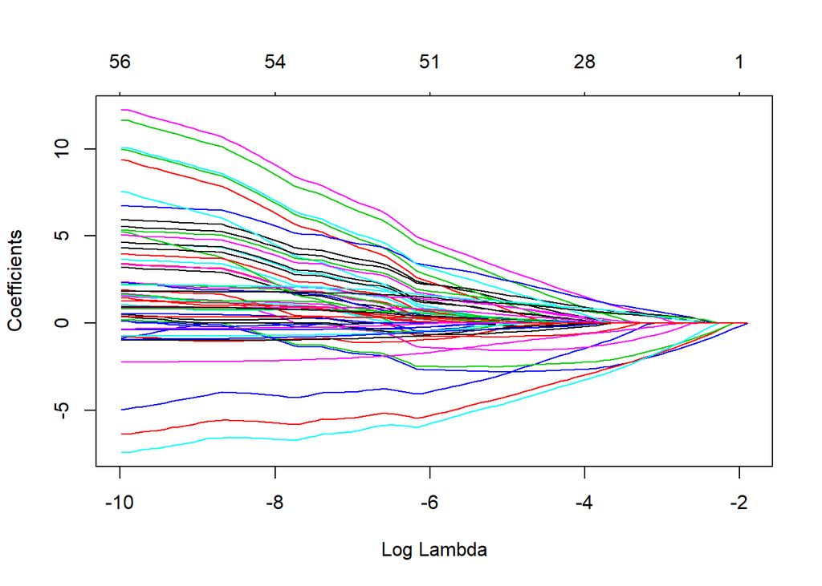

```r
plot(lasso.mod$finalModel, xvar="lambda")
```

```r
bestlam <- lasso.mod$bestTune['lambda']
paste("Best Lambda value from CV=", bestlam)
```

```
## [1] "Best Lambda value from CV= 0.01"
```

```r
lasso.pred= predict(lasso.mod, s=bestlam, chi_validation2[,-which(names(chi_validation2) == "Absenteeism")])
cm <- confusionMatrix(lasso.pred, chi_validation2$Absenteeism, positive = "0")
print(cm)
```

```
## Confusion Matrix and Statistics
##
##           Reference
## Prediction  0  1
##          0 78  9
##          1 15 41
##
##                Accuracy : 0.8322
##                  95% CI : (0.7606, 0.8894)
##     No Information Rate : 0.6503
##     P-Value [Acc > NIR] : 1.132e-06
##
##                   Kappa : 0.6409
##
##  Mcnemar's Test P-Value : 0.3074
##
##             Sensitivity : 0.8387
##             Specificity : 0.8200
##          Pos Pred Value : 0.8966
##          Neg Pred Value : 0.7321
##              Prevalence : 0.6503
##          Detection Rate : 0.5455
##    Detection Prevalence : 0.6084
##       Balanced Accuracy : 0.8294
##
##        'Positive' Class : 0
##
```

Take a look to the features selected by the lasso model (only those with importance larger than 0)

```r
# Print, plot variable importance
imp <- varImp(lasso.mod$finalModel)
names <- rownames(imp)[order(imp$Overall, decreasing=TRUE)]
importance <- imp[names,]

filter(data.frame(names, importance), importance > 0.0)
```

| names | importance |
| --- | --- |
| Disciplinary.failure1 | 4.044418788 |
| Reason.for.absencephysiotherapy | 3.696445249 |
| Reason.for.absencemedical_consultation | 2.753636821 |
| Reason.for.absenceDiseases_of_the_eye_and_adnexa | 2.433647658 |
| Reason.for.absencedental_consultation | 2.373178804 |
| Reason.for.absenceCongenital_malformations_deformations_and_chromosomal_abnormalities | 2.293641354 |
| Reason.for.absenceDiseases_of_the_digestive_system | 2.066342492 |
| Reason.for.absenceDiseases_of_the_respiratory_system | 1.836675678 |
| Reason.for.absencelaboratory_examination | 1.539832997 |
| Reason.for.absenceblood_donation | 1.359461517 |

[output cut: 26 more lines]